# 2015-11-17 lognote

## ToDo

- ADC/DAC のレジスタ read/write のエンバグ前バージョンでレジスタテスト
  - `git checkout` して戻るまえに rbcp.vhd のソースを確認したら、ちょっとまずそうな部分があったので、その部分を書き換えて implement しなおしたらバグがとれた。
- どのバージョンからエンバグしたかを identify or ソースコード比較でデバッグ
  - なのでやってない
- FPGA に自前レジスタをつかって、それに SiTCP RBCP (UDP) の read/write テスト（ようは memtest）
  - 1 byte read/write ← 1 M times passed!
  - multi-byte read/write ← 1 M times passed!
  - RBCP での書き込みは成功しているので、`rbcp.vhd` の後にバグがあるはず

ADC register 0x42 <= 0x00

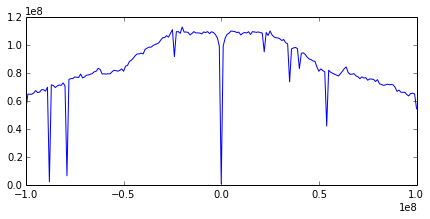

```python
def foo():
    sd = read_sweep('/home/hikaru/readout/data/sweep_20151111_070009.csv')
    fig, ax = plt.subplots(figsize=(7,3))
    ax.plot(sd.freq, sd.amp)

foo()
```

ADC register 0x42 <= 0xF8 # やっぱ delay はいる

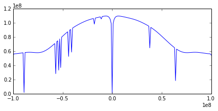

```python
def foo():
    sd = read_sweep('/home/hikaru/readout/data/sweep_20151111_072706.csv')
    fig, ax = plt.subplots(figsize=(7,3))
    ax.plot(sd.freq, sd.amp)

foo()
```

`set_freq2()` で sweep

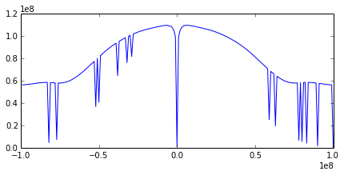

```python
def foo():
    sd = read_sweep('/home/hikaru/readout/data/sweep_20151111_080101.csv')
    fig, ax = plt.subplots(figsize=(7,3))
    ax.plot(sd.freq, sd.amp)

foo()
```

待ち時間なしで `set_freq()` 2 発

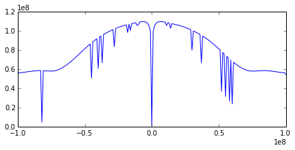

```python
def foo():
    sd = read_sweep('/home/hikaru/readout/data/sweep_20151111_081139.csv')
    fig, ax = plt.subplots(figsize=(7,3))
    ax.plot(sd.freq, sd.amp)

foo()
```

`set_freq([0, freq])`

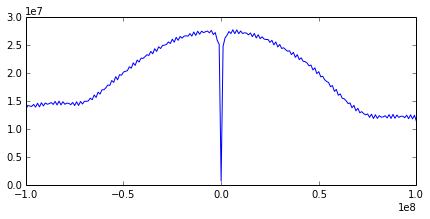

```python
def foo():
    sd = read_sweep('/home/hikaru/readout/data/sweep_20151111_084737.csv')
    fig, ax = plt.subplots(figsize=(7,3))
    ax.plot(sd.freq, sd.amp)

foo()
```

`set_freq([freq, 0])`

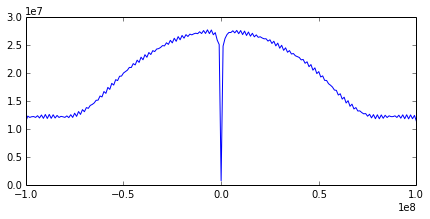

```python
def foo():
    sd = read_sweep('/home/hikaru/readout/data/sweep_20151111_085037.csv')
    fig, ax = plt.subplots(figsize=(7,3))
    ax.plot(sd.freq, sd.amp)

foo()
```

`set_freq([0, freq]) - set_freq([freq, 0])`

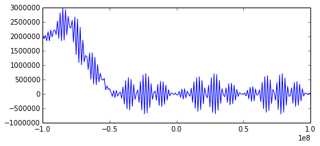

```python
def foo():
    sd0 = read_sweep('/home/hikaru/readout/data/sweep_20151111_084737.csv')
    sd1 = read_sweep('/home/hikaru/readout/data/sweep_20151111_085037.csv')
    fig, ax = plt.subplots(figsize=(7,3))
    ax.plot(sd0.freq, sd0.amp-sd1.amp)

foo()
```

`set_freq([0, freq]) + set_freq([freq, 0])`

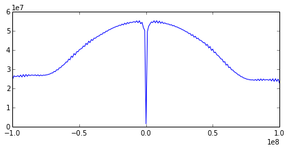

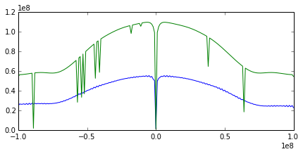

```python
def foo():
    sd0 = read_sweep('/home/hikaru/readout/data/sweep_20151111_084737.csv')
    sd1 = read_sweep('/home/hikaru/readout/data/sweep_20151111_085037.csv')
    fig, ax = plt.subplots(figsize=(7,3))
    ax.plot(sd0.freq, sd0.amp+sd1.amp)

    sd2 = read_sweep('/home/hikaru/readout/data/sweep_20151111_072706.csv')
    fig, ax = plt.subplots(figsize=(7,3))
    ax.plot(sd0.freq, sd0.amp+sd1.amp)
    ax.plot(sd2.freq, sd2.amp)

foo()
```

`set_freq([freq, 0])` で 0.1 MHz 間隔でとった

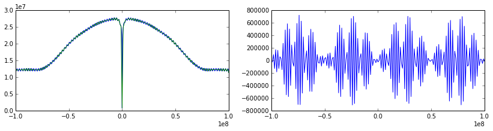

```python
def foo():
    sd0 = read_sweep('/home/hikaru/readout/data/sweep_20151111_090309.csv') # step 0.1 MHz
    sd1 = read_sweep('/home/hikaru/readout/data/sweep_20151111_085037.csv') # step 1 MHz

    fig, ax = plt.subplots(figsize=(14,3), ncols=2)
    ax[0].plot(sd0.freq, sd0.amp)
    ax[0].plot(sd1.freq, sd1.amp)
    ax[1].plot(sd1.freq, sd0.amp[::10]-sd1.amp)

foo()
```

レジスタバグフィックス後のかもめ

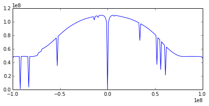

```python
def foo():
    sd = read_sweep('/home/hikaru/readout/data/sweep_20151112_131223.csv')
    fig, ax = plt.subplots(figsize=(7,3))
    ax.plot(sd.freq, sd.amp)

foo()
```

`dac_sum.vhd` の output signal に buffer をかませた。

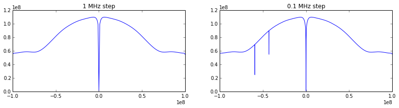

```python
def foo():
    sd0 = read_sweep('/home/hikaru/readout/data/sweep_20151113_143402.csv')
    sd1 = read_sweep('/home/hikaru/readout/data/sweep_20151113_143534.csv')
    fig, ax = plt.subplots(figsize=(14,3), ncols=2)
    ax[0].plot(sd0.freq, sd0.amp); #ax[0].set_yscale('log')
    ax[1].plot(sd1.freq, sd1.amp); #ax[1].set_yscale('log')
    ax[0].set_title('1 MHz step')
    ax[1].set_title('0.1 MHz step')

    p = bp.figure(width=600, height=250)
    p.line(sd1.freq, sd1.amp)
    bp.show(p)

foo()
```

0.1 MHz step でとったほうの跳ねている 2 つの周波数（-59.3e6 Hz, -42.9e6 Hz）とその前後の raw data

buffering して明らかに跳ねる頻度は減ったようにみえる

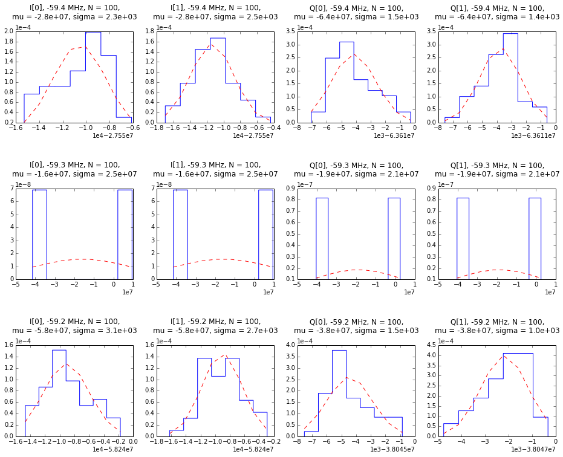

```python
def foo():
    sd = read_sweep('/home/hikaru/readout/data/sweep_20151113_143534.csv')
    ind = np.where(sd.freq == -59.3e6)[0][0]
#     hist_iq(sd[ind:ind+1])
    hist_iq(sd[ind-1:ind+2])

foo()
```

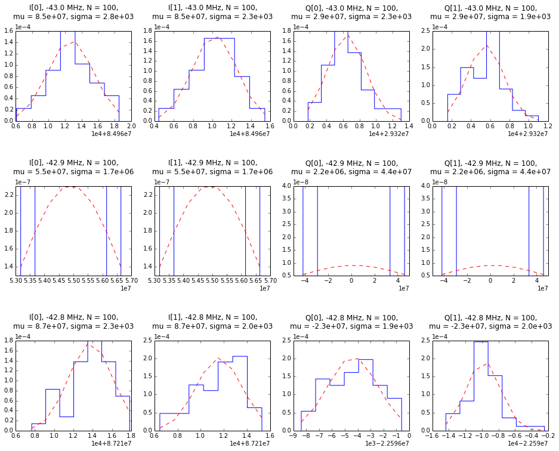

```python
def foo():
    sd = read_sweep('/home/hikaru/readout/data/sweep_20151113_143534.csv')
    ind = np.where(sd.freq == -42.9e6)[0][0]
    hist_iq(sd[ind-1:ind+2])

foo()
```

デジタルで閉じた場合のかもめ

リニアスケールでみると dip（0 Hz と 25 MHz 間隔にあるやつ）が見えるが 0.01% 以下の減衰なので今の問題とは異なる。ヒストグラムをプロットしてみると値がすべて同じになっている。

[output not shown]

[output cut: 29 more lines]

[output not shown]

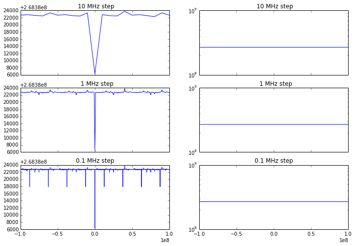

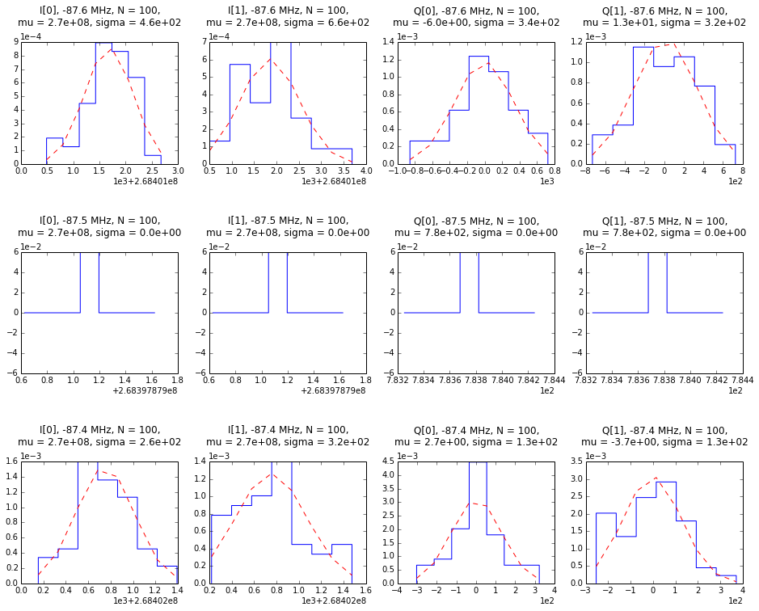

```python
def foo():
    sd0 = read_sweep('/home/hikaru/readout/data/sweep_20151114_083351.csv')
    sd1 = read_sweep('/home/hikaru/readout/data/sweep_20151114_083433.csv')
    sd2 = read_sweep('/home/hikaru/readout/data/sweep_20151114_085120.csv')
    fig, ax = plt.subplots(figsize=(12,8), ncols=2, nrows=3, sharex=True)
    ax[0,0].plot(sd0.freq, sd0.amp); ax[0,0].set_title(' 10 MHz step')
    ax[1,0].plot(sd1.freq, sd1.amp); ax[1,0].set_title('  1 MHz step')
    ax[2,0].plot(sd2.freq, sd2.amp); ax[2,0].set_title('0.1 MHz step')
    ax[0,1].plot(sd0.freq, sd0.amp); ax[0,1].set_title(' 10 MHz step'); ax[0,1].set_yscale('log')
    ax[1,1].plot(sd1.freq, sd1.amp); ax[1,1].set_title('  1 MHz step'); ax[1,1].set_yscale('log')
    ax[2,1].plot(sd2.freq, sd2.amp); ax[2,1].set_title('0.1 MHz step'); ax[2,1].set_yscale('log')

    for i in np.where(sd2.amp < 20000+2.6838e8)[0]:
        print '%+.2e Hz' % sd2.freq[i]
    ind = np.where(sd2.amp < 20000+2.6838e8)[0][0]
    hist_iq(sd2[ind-1:ind+2])
    print sd2[ind:ind+1].freq, sd2[ind:ind+1].i_raw, sd2[ind:ind+1].q_raw

foo()
```

同じくデジタルで閉じたかもめ。DDS の設定を streaming から programmable に変更。

かもめを見る限り変化はない。

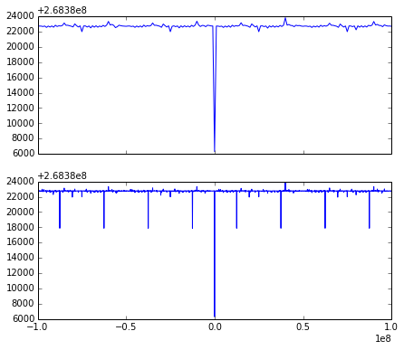

```python
def foo():
    sd = []
    sd.append(read_sweep('/home/hikaru/readout/data/sweep_20151116_065413.csv'))
    sd.append(read_sweep('/home/hikaru/readout/data/sweep_20151116_065746.csv'))
    fig, ax = plt.subplots(figsize=(7,6), nrows=2, sharex=True)
    ax[0].plot(sd[0].freq, sd[0].amp)
    ax[1].plot(sd[1].freq, sd[1].amp)

foo()
```

phase offset を実装。25 MHz の cosine/sine wave を 0° と 180° でシミュレートしてプロット。

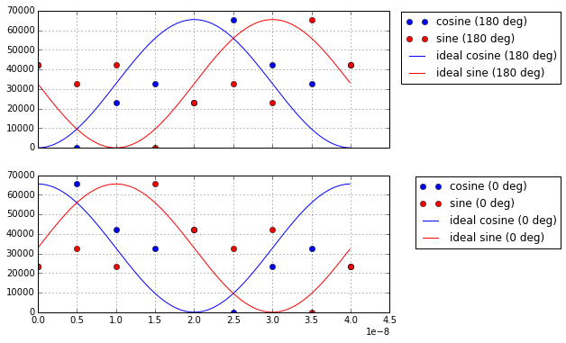

```python
def foo():
    cos_180 = [0xa580, 0x0002, 0x5a82, 0x7ffe, 0x5a80, 0xfffe, 0xa57e, 0x8002, 0xa580]
    sin_180 = [0xa57e, 0x8002, 0xa580, 0x0002, 0x5a82, 0x7ffe, 0x5a80, 0xfffe, 0xa57e]
    cos_0   = [0x5a80, 0xfffe, 0xa57e, 0x8002, 0xa580, 0x0002, 0x5a82, 0x7ffe, 0x5a80]
    sin_0   = [0x5a82, 0x7ffe, 0x5a80, 0xfffe, 0xa57e, 0x8002, 0xa580, 0x0002, 0x5a82]

    x  = np.arange(9)/200e6
    x_ = np.arange(0, 4e-8, 1e-10)
    fig, ax = plt.subplots(figsize=(7,6), nrows=2, sharex=True)
    ax[0].plot(x, cos_180, 'o', label='cosine (180 deg)')
    ax[0].plot(x, sin_180, 'ro', label='sine (180 deg)')
    ax[0].plot(x_, 0x8000+0x8000*np.cos(2*np.pi*25e6*x_ + np.pi), 'b-', label='ideal cosine (180 deg)')
    ax[0].plot(x_, 0x8000+0x8000*np.sin(2*np.pi*25e6*x_ + np.pi), 'r-', label='ideal sine (180 deg)')

    ax[1].plot(x, cos_0, 'o', label='cosine (0 deg)')
    ax[1].plot(x, sin_0, 'ro', label='sine (0 deg)')
    ax[1].plot(x_, 0x8000+0x8000*np.cos(2*np.pi*25e6*x_), 'b-', label='ideal cosine (0 deg)')
    ax[1].plot(x_, 0x8000+0x8000*np.sin(2*np.pi*25e6*x_), 'r-', label='ideal sine (0 deg)')

    ax[0].legend(bbox_to_anchor=(1.5, 1.03)); ax[0].grid()
    ax[1].legend(bbox_to_anchor=(1.5, 1.03)); ax[1].grid()

foo()
```

```python
%matplotlib inline
import numpy as np
import matplotlib.pyplot as plt
from scipy.stats import norm
import bokeh.plotting as bp
bp.output_notebook()
```

BokehJS successfully loaded.

```python
class SweepDataError(Exception):
    def __init_(self, msg):
        self.msg = 'SweepData Error: %s' % str(msg)

    def __str__(self):
        return self.msg

class SweepData(object):
    def __init__(self, freq, i, q, i_raw=None, q_raw=None):
        self.freq  = np.array(freq)
        self.i     = np.array(i)
        self.q     = np.array(q)
        self.i_raw = np.array(i_raw) if i_raw is not None else None
        self.q_raw = np.array(q_raw) if q_raw is not None else None
        if self.i_raw is not None:
            self.ch     = len(self.i_raw)
            self.sample = len(self.i_raw[0][0])

    def __getitem__(self, key):
        if not isinstance(key, slice):
            raise ValueError('SweepData.__getitem__ does not suppots it.')

        if self.i_raw is None:
            return SweepData(self.freq[key], self.i[key], self.q[key])
        else:
            return SweepData(self.freq[key], self.i[key], self.q[key],
                            [self.i_raw[c][key] for c in range(self.ch)],
                            [self.q_raw[c][key] for c in range(self.ch)])

    def __len__(self):
        return len(self.freq)

    @property
    def amp(self):
        return np.abs(self.i + 1j* self.q)

def read_sweep(fname, nchan=2, skiprows=10, skipfooter=None, comment='#', delimiter=','):
    with open(fname, 'r') as f:
        lines = f.readlines()

    if skipfooter is not None:
        lines = lines[skiprows:-skipfooter]
    else:
        lines = lines[skiprows:]

    d_unit = len(lines[0].split(delimiter)) # this value is 3 if -r option is not set

    freq  = []
    i     = []
    q     = []
    i_raw = [list() for k in range(nchan)] if d_unit > 3 else None
    q_raw = [list() for k in range(nchan)] if d_unit > 3 else None
    for line in lines:
        if line[0] == comment: continue
        l = [float(x) for x in line.split(delimiter)]
        freq.append(l[0])
        i.append(l[1])
        q.append(l[2])
        if i_raw is None: continue
        sample = (len(l) - 3) / (nchan*2)
        for ch in range(nchan):
            i_raw[ch].append(l[       ch *sample+3 :       (ch+1)*sample+3])
            q_raw[ch].append(l[(nchan+ch)*sample+3 : (nchan+ch+1)*sample+3])

    if i_raw is None:
        return SweepData(freq, i, q)
    else:
        return SweepData(freq, i, q, i_raw, q_raw)

sd = read_sweep('/home/hikaru/readout/data/sweep_20151030_094910.csv')
```

```python
def hist_iq(SweepData, histtype='step'):
    nrows = len(SweepData)
    fig, ax = plt.subplots(ncols=4, nrows=nrows, figsize=(16, nrows*4))
    if nrows == 1: ax = np.array([ax])
    for j in xrange(nrows):
        n0, bins0, patches0 = ax[j][0].hist(SweepData.i_raw[0][j], normed=True, bins=np.log2(SweepData.sample)+1, histtype=histtype)
        n1, bins1, patches1 = ax[j][1].hist(SweepData.i_raw[1][j], normed=True, bins=np.log2(SweepData.sample)+1, histtype=histtype)
        n2, bins2, patches2 = ax[j][2].hist(SweepData.q_raw[0][j], normed=True, bins=np.log2(SweepData.sample)+1, histtype=histtype)
        n3, bins3, patches3 = ax[j][3].hist(SweepData.q_raw[1][j], normed=True, bins=np.log2(SweepData.sample)+1, histtype=histtype)
        # fit
        mu0, sigma0 = norm.fit(SweepData.i_raw[0][j])
        mu1, sigma1 = norm.fit(SweepData.i_raw[1][j])
        mu2, sigma2 = norm.fit(SweepData.q_raw[0][j])
        mu3, sigma3 = norm.fit(SweepData.q_raw[1][j])
        y0 = norm.pdf(bins0, mu0, sigma0)
        y1 = norm.pdf(bins1, mu1, sigma1)
        y2 = norm.pdf(bins2, mu2, sigma2)
        y3 = norm.pdf(bins3, mu3, sigma3)
        ax[j][0].plot(bins0, y0, 'r--')
        ax[j][1].plot(bins1, y1, 'r--')
        ax[j][2].plot(bins2, y2, 'r--')
        ax[j][3].plot(bins3, y3, 'r--')
        ax[j][0].set_title('I[0], %.1f MHz, N = %d,\nmu = %.1e, sigma = %.1e\n' % (SweepData.freq[j]/1e6, len(SweepData.i_raw[0][j]), mu0, sigma0))
        ax[j][1].set_title('I[1], %.1f MHz, N = %d,\nmu = %.1e, sigma = %.1e\n' % (SweepData.freq[j]/1e6, len(SweepData.i_raw[1][j]), mu1, sigma1))
        ax[j][2].set_title('Q[0], %.1f MHz, N = %d,\nmu = %.1e, sigma = %.1e\n' % (SweepData.freq[j]/1e6, len(SweepData.q_raw[0][j]), mu2, sigma2))
        ax[j][3].set_title('Q[1], %.1f MHz, N = %d,\nmu = %.1e, sigma = %.1e\n' % (SweepData.freq[j]/1e6, len(SweepData.q_raw[1][j]), mu3, sigma3))
        fig.subplots_adjust(hspace=0.72)
        for k in range(4):
            ax[j][k].ticklabel_format(style='sci', axis='both', scilimits=(0, 0))

# hist_iq(read_sweep('/home/hikaru/airPupa/sweep_20151014_130453.csv'))
```